# Assignment_2_Rahul_Gupta_1

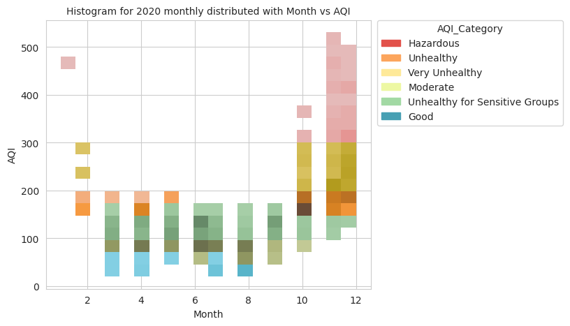

```python
#Histogram for 2020 monthly distributed with Month vs AQI

fig = plt.figure(figsize=(6,5))

hist_monthly_6 = Final_file[Final_file['Year'] == 2020]

plt.title('Histogram for 2020 monthly distributed with Month vs AQI',fontsize='medium')

ax = sns.histplot(data=hist_monthly_6,x=Final_file.Month, y=Final_file.AQI, palette = "Spectral", hue="AQI_Category",bins=20, legend='auto')
sns.move_legend(ax, "upper left", bbox_to_anchor=(1.02, 1),borderaxespad=0)

plt.show()
```

For 2020, it seems that the histogram is of multimodial distribution has both sides has maximum values for aqi.

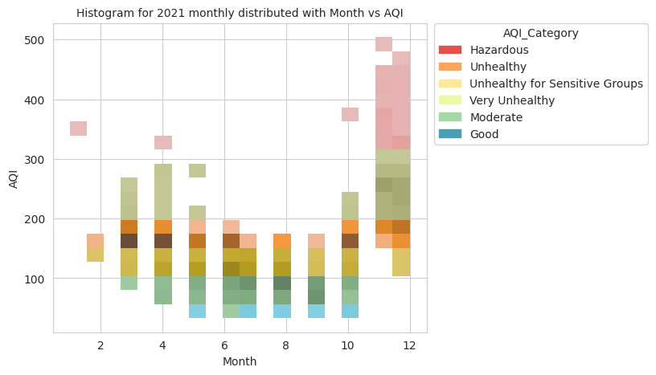

```python
#Histogram for 2021 monthly distributed with Month vs AQI

fig = plt.figure(figsize=(6,5))

hist_monthly_7 = Final_file[Final_file['Year'] == 2021]

plt.title('Histogram for 2021 monthly distributed with Month vs AQI',fontsize='medium')

ax = sns.histplot(data=hist_monthly_7,x=Final_file.Month, y=Final_file.AQI, palette = "Spectral", hue="AQI_Category",bins=20, legend='auto')
sns.move_legend(ax, "upper left", bbox_to_anchor=(1.02, 1),borderaxespad=0)

plt.show()
```

For 2021, there seems to be a wave type of distribution with bimodial distribution in plot.

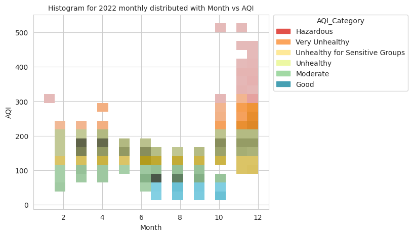

```python
#Histogram for 2022 monthly distributed with Month vs AQI

fig = plt.figure(figsize=(6,5))

hist_monthly_8 = Final_file[Final_file['Year'] == 2022]

plt.title('Histogram for 2022 monthly distributed with Month vs AQI',fontsize='medium')

ax = sns.histplot(data=hist_monthly_8,x=Final_file.Month, y=Final_file.AQI, palette = "Spectral", hue="AQI_Category",bins=20, legend='auto')
sns.move_legend(ax, "upper left", bbox_to_anchor=(1.02, 1),borderaxespad=0)

plt.show()
```

For 2022, graph seems to be bimodial distributed.

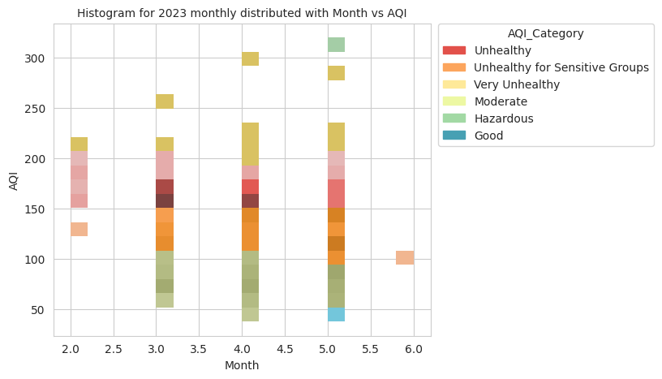

```python
#Histogram for 2023 monthly distributed with Month vs AQI

fig = plt.figure(figsize=(6,5))

hist_monthly_9 = Final_file[Final_file['Year'] == 2023]

plt.title('Histogram for 2023 monthly distributed with Month vs AQI',fontsize='medium')

ax = sns.histplot(data=hist_monthly_9,x=Final_file.Month.astype(int), y=Final_file.AQI, palette = "Spectral", hue="AQI_Category",bins=20, legend='auto')
sns.move_legend(ax, "upper left", bbox_to_anchor=(1.02, 1),borderaxespad=0)

plt.show()
```

For 2023, it seems to be left skewed with an upward trend.

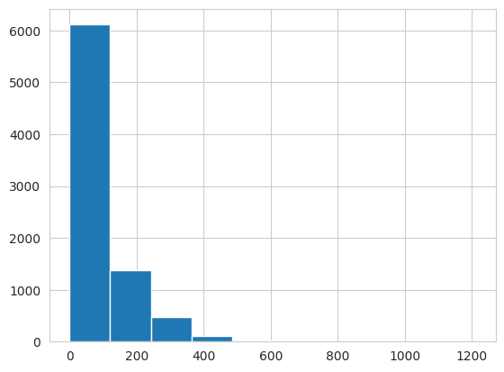

```python
#Plotting histogram for NowCast_Conc

plt.hist(Final_file.NowCast_Conc)
```

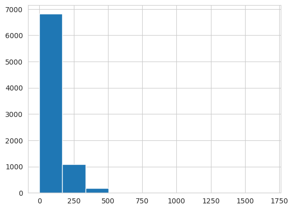

```python
#Plotting histogram for Raw_Conc

plt.hist(Final_file.Raw_Conc)
```

Systematic sampling and building new and final cleaned dataset.

### For sampling using systematic method I will dive into monthly chart and select the first 4 days with the highest peak

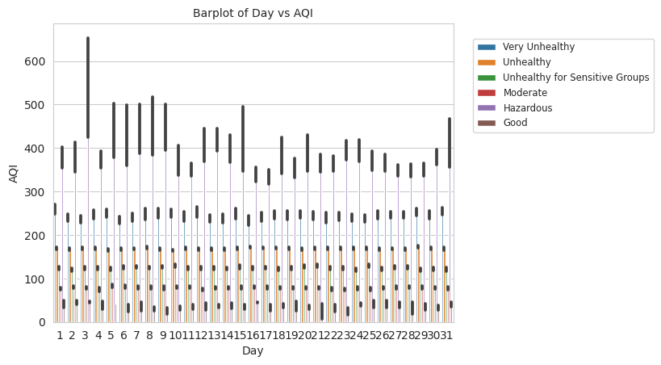

```python
sns.barplot(x=Final_file['Day'],y=Final_file['AQI'],hue=Final_file['AQI_Category'])
plt.legend(bbox_to_anchor=(1.05, 0.95),fontsize='small',borderaxespad=0, fancybox=None)

plt.title('Barplot of Day vs AQI',fontsize='medium')
```

```python
#I can see that day 3, 5, 6 & 8 has the highest AQI and hence I will choose them to learn more from systematic samplic
#and more levels
```

```python
Final_file_2=Final_file
Final_file_2
```

|  | level_0 | index | Site | Parameter | Date_LT | Year | Month | Day | Hour | NowCast_Conc | AQI | AQI_Category | Raw_Conc | Conc_Unit | Duration | QC_Name |
| --- | --- | --- | --- | --- | --- | --- | --- | --- | --- | --- | --- | --- | --- | --- | --- | --- |
| 0 | 1 | 1301 | New Delhi | PM2.5 - Principal | 2015-02-24 06:00 AM | 2015 | 2 | 24 | 6 | 182.4 | 233 | Very Unhealthy | 179.0 | UG/M3 | 1 Hr | Valid |
| 1 | 7 | 1307 | New Delhi | PM2.5 - Principal | 2015-02-24 12:00 PM | 2015 | 2 | 24 | 12 | 217.1 | 267 | Very Unhealthy | 190.0 | UG/M3 | 1 Hr | Valid |
| 2 | 13 | 1313 | New Delhi | PM2.5 - Principal | 2015-02-24 06:00 PM | 2015 | 2 | 24 | 18 | 142.0 | 196 | Unhealthy | 146.0 | UG/M3 | 1 Hr | Valid |
| 3 | 19 | 1319 | New Delhi | PM2.5 - Principal | 2015-02-25 12:00 AM | 2015 | 2 | 25 | 0 | 179.1 | 229 | Very Unhealthy | 181.0 | UG/M3 | 1 Hr | Valid |
| 4 | 25 | 1325 | New Delhi | PM2.5 - Principal | 2015-02-25 06:00 AM | 2015 | 2 | 25 | 6 | 144.3 | 197 | Unhealthy | 124.0 | UG/M3 | 1 Hr | Valid |
| ... | ... | ... | ... | ... | ... | ... | ... | ... | ... | ... | ... | ... | ... | ... | ... | ... |
| 8158 | 49053 | 3598 | New Delhi | PM2.5 - Principal | 2023-05-31 12:00 AM | 2023 | 5 | 31 | 0 | 28.1 | 85 | Moderate | 32.0 | UG/M3 | 1 Hr | Valid |
| 8159 | 49059 | 3604 | New Delhi | PM2.5 - Principal | 2023-05-31 06:00 AM | 2023 | 5 | 31 | 6 | 44.5 | 123 | Unhealthy for Sensitive Groups | 27.0 | UG/M3 | 1 Hr | Valid |
| 8160 | 49065 | 3610 | New Delhi | PM2.5 - Principal | 2023-05-31 12:00 PM | 2023 | 5 | 31 | 12 | 17.4 | 62 | Moderate | 11.0 | UG/M3 | 1 Hr | Valid |
| 8161 | 49071 | 3616 | New Delhi | PM2.5 - Principal | 2023-05-31 06:00 PM | 2023 | 5 | 31 | 18 | 11.0 | 46 | Good | 6.0 | UG/M3 | 1 Hr | Valid |
| 8162 | 49077 | 3622 | New Delhi | PM2.5 - Principal | 2023-06-01 12:00 AM | 2023 | 6 | 1 | 0 | 38.0 | 107 | Unhealthy for Sensitive Groups | 44.0 | UG/M3 | 1 Hr | Valid |

8141 rows × 16 columns

```python
#I can see that day 3, 5, 6 & 8 has the highest AQI and hence I will choose them to learn more from systematic samplic
#and more levels

index_hr_year = Final_file_2[ ~((Final_file_2['Day'] == 3) | (Final_file_2['Day'] == 5)| (Final_file_2['Day'] == 6)|
                         (Final_file_2['Day'] == 8))].index
index_hr_year
```

```
Int64Index([   0,    1,    2,    3,    4,    5,    6,    7,    8,    9,
            ...
            8153, 8154, 8155, 8156, 8157, 8158, 8159, 8160, 8161, 8162],
           dtype='int64', length=7084)
```

```python
#Now I will observe which hour to choose
```

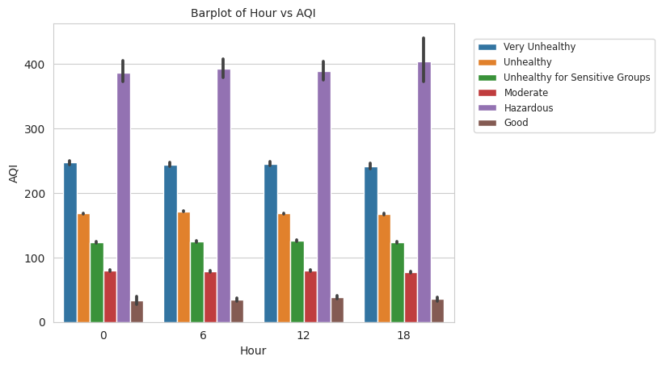

```python
sns.barplot(x=Final_file['Hour'],y=Final_file['AQI'],hue=Final_file['AQI_Category'])
plt.legend(bbox_to_anchor=(1.05, 0.95),fontsize='small',borderaxespad=0, fancybox=None)
plt.title('Barplot of Hour vs AQI',fontsize='medium')
```

```python
#From above graph it is clear that the peak is around 18pm meaning I need to check more on that. Even though it is not
#that high I will choose it for the systematic sampling process

#So the final rule for systematic sampling method is to choose day 3, 5, 6 & 8 and hour to be 18
```

```python
#Creating new indexing for our systematic sample

index_sample_final = Final_file_2[ ~(((Final_file_2['Day'] == 3) & (Final_file_2['Hour'] == 18))
                                     | ((Final_file_2['Day'] == 5) &(Final_file_2['Hour'] == 18))
                                     | ((Final_file_2['Day'] == 6) &(Final_file_2['Hour'] == 18))|
                         ((Final_file_2['Day'] == 8) &(Final_file_2['Hour'] == 18)))].index
print(f'index_sample_final: {index_sample_final} and length is: {len(index_sample_final)}')
print(f'So our final dataset after sampling is {int(len(Final_file_2))-int(len(index_sample_final))}')
```

```
index_sample_final: Int64Index([   0,    1,    2,    3,    4,    5,    6,    7,    8,    9,
            ...
            8153, 8154, 8155, 8156, 8157, 8158, 8159, 8160, 8161, 8162],
           dtype='int64', length=7882) and length is: 7882
So our final dataset after sampling is 259
```

```python
#Dropping the rest of the data set
Final_file_2.drop(index_sample_final , inplace=True)
print(f'New shape with Final_file_2 is {Final_file_2.shape}')
```

```
New shape with Final_file_2 is (259, 16)
```

```python
#It seems the final data set after sampling and all cleaning is ready
#Exporting it to a new csv file
Final_file_2.to_csv('systematic_cleaned_file.csv') #saving the file
```

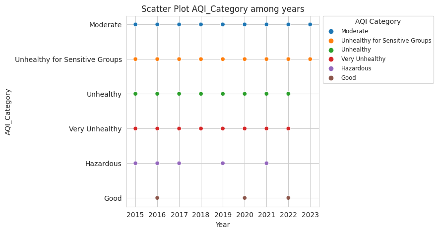

```python
#Scatterplot for trend of AQI_Category vs Years
plt.figure(figsize=(5, 5))
sns.set_style('whitegrid') #whitegrid, darkgrid, dark, white


scatter_plot = sns.scatterplot(x=Final_file_2.Year, y=Final_file_2.AQI_Category, hue=Final_file_2.AQI_Category)
scatter_plot.set_title('Scatter Plot AQI_Category among years')
scatter_plot.legend(title='AQI Category', fontsize='small',bbox_to_anchor=(1.02, 1), borderaxespad=0, fancybox=None)

plt.show()
```

For AQI_Category comparison among all years, it seems that all years has moderate category with unhealthy for sensitive groups. While 2016, 202 & 2022 has a good category, Hazardous category is to be seen in 5 years.

```python
corr = Final_file_2.corr(numeric_only=True)
corr
```

|  | level_0 | index | Year | Month | Day | Hour | NowCast_Conc | AQI | Raw_Conc |
| --- | --- | --- | --- | --- | --- | --- | --- | --- | --- |
| level_0 | 1.000000 | 0.009154 | 0.992744 | 0.056512 | 0.003576 | NaN | -0.069227 | -0.078916 | -0.081662 |
| index | 0.009154 | 1.000000 | -0.109891 | 0.990286 | 0.010081 | NaN | 0.397424 | 0.444039 | 0.380448 |
| Year | 0.992744 | -0.109891 | 1.000000 | -0.062949 | 0.002389 | NaN | -0.115294 | -0.130929 | -0.125380 |
| Month | 0.056512 | 0.990286 | -0.062949 | 1.000000 | -0.012509 | NaN | 0.386439 | 0.433491 | 0.367830 |
| Day | 0.003576 | 0.010081 | 0.002389 | -0.012509 | 1.000000 | NaN | 0.015939 | 0.013877 | 0.003036 |
| Hour | NaN | NaN | NaN | NaN | NaN | NaN | NaN | NaN | NaN |
| NowCast_Conc | -0.069227 | 0.397424 | -0.115294 | 0.386439 | 0.015939 | NaN | 1.000000 | 0.979257 | 0.989902 |
| AQI | -0.078916 | 0.444039 | -0.130929 | 0.433491 | 0.013877 | NaN | 0.979257 | 1.000000 | 0.965216 |
| Raw_Conc | -0.081662 | 0.380448 | -0.125380 | 0.367830 | 0.003036 | NaN | 0.989902 | 0.965216 | 1.000000 |

```python
Final_file_3=Final_file_2
Final_file_3
```

|  | level_0 | index | Site | Parameter | Date_LT | Year | Month | Day | Hour | NowCast_Conc | AQI | AQI_Category | Raw_Conc | Conc_Unit | Duration | QC_Name |
| --- | --- | --- | --- | --- | --- | --- | --- | --- | --- | --- | --- | --- | --- | --- | --- | --- |
| 27 | 162 | 1529 | New Delhi | PM2.5 - Principal | 2015-03-05 06:00 PM | 2015 | 3 | 5 | 18 | 31.9 | 93 | Moderate | 32.0 | UG/M3 | 1 Hr | Valid |
| 31 | 186 | 1553 | New Delhi | PM2.5 - Principal | 2015-03-06 06:00 PM | 2015 | 3 | 6 | 18 | 32.6 | 94 | Moderate | 37.0 | UG/M3 | 1 Hr | Valid |
| 39 | 234 | 1601 | New Delhi | PM2.5 - Principal | 2015-03-08 06:00 PM | 2015 | 3 | 8 | 18 | 19.5 | 67 | Moderate | 22.0 | UG/M3 | 1 Hr | Valid |
| 130 | 782 | 2225 | New Delhi | PM2.5 - Principal | 2015-04-03 06:00 PM | 2015 | 4 | 3 | 18 | 39.0 | 110 | Unhealthy for Sensitive Groups | 46.0 | UG/M3 | 1 Hr | Valid |
| 138 | 830 | 2273 | New Delhi | PM2.5 - Principal | 2015-04-05 06:00 PM | 2015 | 4 | 5 | 18 | 58.7 | 153 | Unhealthy | 62.0 | UG/M3 | 1 Hr | Valid |
| ... | ... | ... | ... | ... | ... | ... | ... | ... | ... | ... | ... | ... | ... | ... | ... | ... |
| 7975 | 47966 | 2272 | New Delhi | PM2.5 - Principal | 2023-04-05 06:00 PM | 2023 | 4 | 5 | 18 | 23.4 | 75 | Moderate | 21.0 | UG/M3 | 1 Hr | Valid |
| 7979 | 47988 | 2296 | New Delhi | PM2.5 - Principal | 2023-04-06 06:00 PM | 2023 | 4 | 6 | 18 | 12.8 | 52 | Moderate | 11.0 | UG/M3 | 1 Hr | Valid |
| 8070 | 48539 | 2944 | New Delhi | PM2.5 - Principal | 2023-05-03 06:00 PM | 2023 | 5 | 3 | 18 | 20.0 | 68 | Moderate | 21.0 | UG/M3 | 1 Hr | Valid |
| 8078 | 48586 | 2992 | New Delhi | PM2.5 - Principal | 2023-05-05 06:00 PM | 2023 | 5 | 5 | 18 | 46.9 | 129 | Unhealthy for Sensitive Groups | 45.0 | UG/M3 | 1 Hr | Valid |
| 8089 | 48656 | 3064 | New Delhi | PM2.5 - Principal | 2023-05-08 06:00 PM | 2023 | 5 | 8 | 18 | 28.2 | 85 | Moderate | 29.0 | UG/M3 | 1 Hr | Valid |

259 rows × 16 columns

```python
Final_file_3.head(0)
```

|  | level_0 | index | Site | Parameter | Date_LT | Year | Month | Day | Hour | NowCast_Conc | AQI | AQI_Category | Raw_Conc | Conc_Unit | Duration | QC_Name |
| --- | --- | --- | --- | --- | --- | --- | --- | --- | --- | --- | --- | --- | --- | --- | --- | --- |

```python
Final_file_3.drop(columns=['level_0','index','Site','Parameter','Date_LT','Month','Day','Hour','NowCast_Conc','Raw_Conc','Conc_Unit','Duration','QC_Name'], axis=1, inplace=True)
```

```python
Final_file_3.shape
```

```
(259, 3)
```

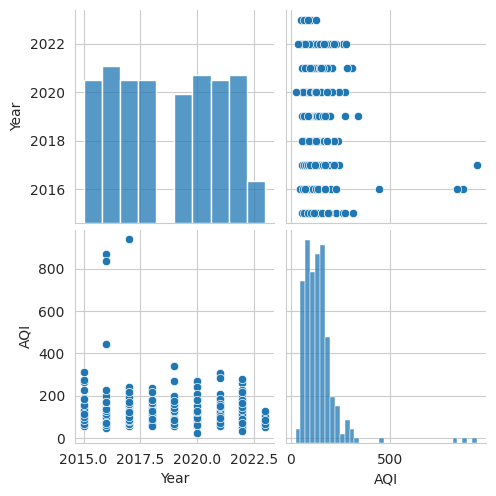

```python
sns.pairplot(Final_file_3, kind="scatter")
plt.show()
```

```python
Final_file_3.reset_index(inplace=True)
```

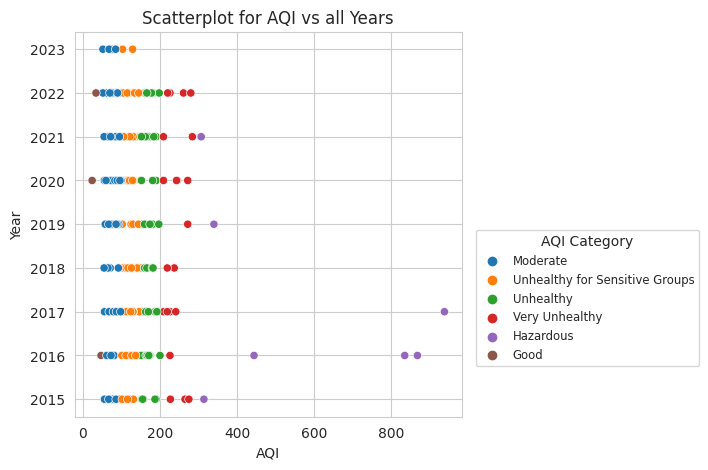

```python
#Scatterplot for AQI vs all Years

plt.figure(figsize=(5, 5))
sns.set_style('whitegrid')


scatter_plot = sns.scatterplot(data=Final_file_3, x='AQI', y='Year', hue='AQI_Category')
scatter_plot.set_title('Scatterplot for AQI vs all Years')
scatter_plot.legend(title='AQI Category', fontsize='small',bbox_to_anchor=(1.02, 0.5))

plt.show()
```

```python
Final_file_3
```

|  | index | Year | AQI | AQI_Category |
| --- | --- | --- | --- | --- |
| 0 | 27 | 2015 | 93 | Moderate |
| 1 | 31 | 2015 | 94 | Moderate |
| 2 | 39 | 2015 | 67 | Moderate |
| 3 | 130 | 2015 | 110 | Unhealthy for Sensitive Groups |
| 4 | 138 | 2015 | 153 | Unhealthy |
| ... | ... | ... | ... | ... |
| 254 | 7975 | 2023 | 75 | Moderate |
| 255 | 7979 | 2023 | 52 | Moderate |
| 256 | 8070 | 2023 | 68 | Moderate |
| 257 | 8078 | 2023 | 129 | Unhealthy for Sensitive Groups |
| 258 | 8089 | 2023 | 85 | Moderate |

259 rows × 4 columns

```python
Final_file_3.drop('AQI_Category',axis=1,inplace=True)
Final_file_3
```

|  | index | Year | AQI |
| --- | --- | --- | --- |
| 0 | 27 | 2015 | 93 |
| 1 | 31 | 2015 | 94 |
| 2 | 39 | 2015 | 67 |
| 3 | 130 | 2015 | 110 |
| 4 | 138 | 2015 | 153 |
| ... | ... | ... | ... |
| 254 | 7975 | 2023 | 75 |
| 255 | 7979 | 2023 | 52 |
| 256 | 8070 | 2023 | 68 |
| 257 | 8078 | 2023 | 129 |
| 258 | 8089 | 2023 | 85 |

259 rows × 3 columns

```python
Final_file_3.drop('index',axis=1,inplace=True)
Final_file_3
```

|  | Year | AQI |
| --- | --- | --- |
| 0 | 2015 | 93 |
| 1 | 2015 | 94 |
| 2 | 2015 | 67 |
| 3 | 2015 | 110 |
| 4 | 2015 | 153 |
| ... | ... | ... |
| 254 | 2023 | 75 |
| 255 | 2023 | 52 |
| 256 | 2023 | 68 |
| 257 | 2023 | 129 |
| 258 | 2023 | 85 |

259 rows × 2 columns

For correlation, we are only keeping AQI & years and below are the coefficient.

```python
corr_val = Final_file_3.corr()
corr_val
```

|  | Year | AQI |
| --- | --- | --- |
| Year | 1.000000 | -0.130929 |
| AQI | -0.130929 | 1.000000 |

It seems that Year has almost no or a bit negativ effect and same can be seen by heatmap plotted below.

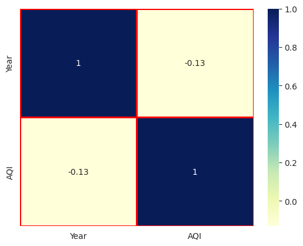

```python
sns.heatmap(corr_val,cmap='YlGnBu',annot=True,linecolor='red',linewidths=1) #cmap=colormap, annot will set values
```

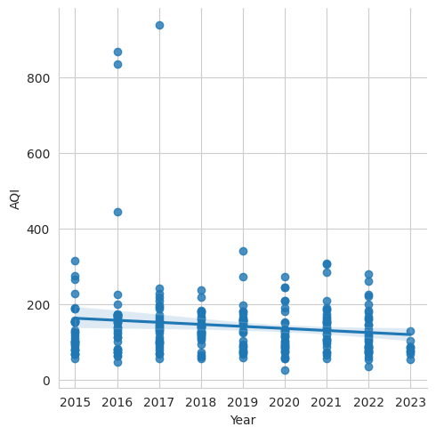

```python
sns.lmplot(x ='Year', y ='AQI', data = Final_file_3)
```

From above, it seems that there is a downward or negative trend from 2015 till 2023 in AQI's value. This proves that coefficient values found above.

```python
%%shell
jupyter nbconvert --to html /content/Assignment_2_Rahul_Gupta.ipynb
```

[output not shown]

[output cut: 133 more lines]

[output not shown]

[output not shown]